Laboratorio 4 - Periodismo de Datos Juvenal Campos 3/2/2020

# Sesión 4. Repaso de estadísticas descriptivas.

En la presente sesión, vamos a repasar nuevamente las estadísticas descriptivas, con la base `efc`, la cual, como vimos en la sesión pasada, contiene información sobre **la situación de los cuidadores de adultos mayores en Europa (proyecto EUROFAMCARE)**.

```r
# Librerias
library(sjmisc)
library(sjlabelled)
library(dplyr)

# Abrimos la base de datos
data(efc)
```

## Conceptos.

**Tablas de contingencia**

*En estadística las tablas de contingencia son tablas que se emplean para registrar y analizar la asociación entre dos o más variables, habitualmente de naturaleza cualitativa (nominales u ordinales).*

Estas tablas nos permiten hacer el famoso *cruce de una variable con otra*.

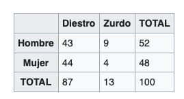

A continuación, un ejemplo:

*Queremos saber en que manera afecta a la salud de los cuidadores el cuidar a sus adultos mayores. Para eso, queremos cruzar la variable de *Relación con el adulto mayor*, `e15relat`, con la variable `c85cop4`,* ¿el acto de cuidar a su adulto mayor ha tenido alguna vez consecuencias en su salud física?*.*

Primero hay que conocer dichas variables (obtener sus etiquetas).

```r
# 1. Obtenemos las claves de las variables previamente mencionadas.

# Etiquetas de relacion
get_labels(efc$e15relat)
```

```
## [1] "spouse/partner"          "child"
## [3] "sibling"                 "daughter or son -in-law"
## [5] "ancle/aunt"              "nephew/niece"
## [7] "cousin"                  "other, specify"
```

```r
# Etiquetas de salud
get_labels(efc$c85cop4)
```

```
## [1] "Never"     "Sometimes" "Often"     "Always"
```

Después de conocer nuestras variables, ya sacamos las tablas de contingencia.

En R, hay dos formas de calcular las tablas de contingencia:

- Una es mediante la función `table()` de R base.
- Otra es mediante la función `flat_table()` que vimos en la sesión pasada, con la librería `sjmisc`.

A continuación utilizaremos ambas maneras:

### Con `table()`

Esta es la función básica para sacar tablas de una o múltiples variables. Si se combina con la función `prop.table()`, vamos a poder sacar la tabla de proporciones.

- Tabla de contingencias con `table()`

```r
table(efc$e15relat, efc$c85cop4)
```

```
##
##       1   2   3   4
##   1  40  78  27  24
##   2 218 181  49  23
##   3  16  11   2   0
##   4  39  35   5   6
##   5  14   8   0   1
##   6  19   3   0   0
##   7   4   1   1   0
##   8  58  29   1   4
```

- Proporciones (a lo largo del renglón)

```r
prop.table(table(efc$e15relat, efc$c85cop4), margin = 1)
```

```
##
##              1          2          3          4
##   1 0.23668639 0.46153846 0.15976331 0.14201183
##   2 0.46284501 0.38428875 0.10403397 0.04883227
##   3 0.55172414 0.37931034 0.06896552 0.00000000
##   4 0.45882353 0.41176471 0.05882353 0.07058824
##   5 0.60869565 0.34782609 0.00000000 0.04347826
##   6 0.86363636 0.13636364 0.00000000 0.00000000
##   7 0.66666667 0.16666667 0.16666667 0.00000000
##   8 0.63043478 0.31521739 0.01086957 0.04347826
```

- Proporciones (a lo largo de la columna)

```r
prop.table(table(efc$e15relat, efc$c85cop4), margin = 2)
```

```
##
##               1           2           3           4
##   1 0.098039216 0.225433526 0.317647059 0.413793103
##   2 0.534313725 0.523121387 0.576470588 0.396551724
##   3 0.039215686 0.031791908 0.023529412 0.000000000
##   4 0.095588235 0.101156069 0.058823529 0.103448276
##   5 0.034313725 0.023121387 0.000000000 0.017241379
##   6 0.046568627 0.008670520 0.000000000 0.000000000
##   7 0.009803922 0.002890173 0.011764706 0.000000000
##   8 0.142156863 0.083815029 0.011764706 0.068965517
```

### Con `flat_table()`

Esta función es la mejor para sacar datos de contingencia cuando tenemos bases de datos etiquetadas.

- Tabla de contingencias con `sjmisc::flat_table()`

```r
flat_table(efc, e15relat, c85cop4)
```

```
##                         c85cop4 Never Sometimes Often Always
## e15relat
## spouse/partner                     40        78    27     24
## child                             218       181    49     23
## sibling                            16        11     2      0
## daughter or son -in-law            39        35     5      6
## ancle/aunt                         14         8     0      1
## nephew/niece                       19         3     0      0
## cousin                              4         1     1      0
## other, specify                     58        29     1      4
```

- Proporciones (a lo largo del renglon)

```r
flat_table(efc, e15relat, c85cop4, margin = "row")
```

```
##                         c85cop4 Never Sometimes Often Always
## e15relat
## spouse/partner                  23.67     46.15 15.98  14.20
## child                           46.28     38.43 10.40   4.88
## sibling                         55.17     37.93  6.90   0.00
## daughter or son -in-law         45.88     41.18  5.88   7.06
## ancle/aunt                      60.87     34.78  0.00   4.35
## nephew/niece                    86.36     13.64  0.00   0.00
## cousin                          66.67     16.67 16.67   0.00
## other, specify                  63.04     31.52  1.09   4.35
```

- Proporciones (a lo largo de la columna)

```r
flat_table(efc, e15relat, c85cop4, margin = "col")
```

```
##                         c85cop4 Never Sometimes Often Always
## e15relat
## spouse/partner                   9.80     22.54 31.76  41.38
## child                           53.43     52.31 57.65  39.66
## sibling                          3.92      3.18  2.35   0.00
## daughter or son -in-law          9.56     10.12  5.88  10.34
## ancle/aunt                       3.43      2.31  0.00   1.72
## nephew/niece                     4.66      0.87  0.00   0.00
## cousin                           0.98      0.29  1.18   0.00
## other, specify                  14.22      8.38  1.18   6.90
```

# Ejercicios.

**Tablas de contingencia**

1. Elabore la tabla de contingencias para `c88cop7` y para `e16sex` utilizando `table()` y `flat_table()`. Explique brevemente a que conclusiones llega.

```r
# Que es la etiqueta?
get_label(efc$c88cop7)
```

```
## [1] "do you feel trapped in your role as caregiver?"
```

```r
# Con flat_table
flat_table(efc, e16sex, c88cop7, margin = "row")
```

```
##        c88cop7 Never Sometimes Often Always
## e16sex
## male           35.81     43.24 11.49   9.46
## female         37.98     40.80 13.10   8.13
```

**Medidas de tendencia central**

2. Obtenga la media y la mediana para las variables `e17age` y `c160age`. Las variables ¿tienen valores faltantes?

Igualmente, obtenga los valores máximos y mínimos, la desviación estándar y los principales cuantiles.

```r
# Media
efc %>%
  summarise(media_e17age = mean(e17age, na.rm = T),
            media_c160age = mean(c160age, na.rm = T),
            mediana_e17age = median(e17age, na.rm = T),
            mediana_c160age = median(c160age, na.rm = T),
            sd_e17age = sd(e17age, na.rm = T),
            sd_c160age = sd(c160age, na.rm = T)
            )
```

```
##   media_e17age media_c160age mediana_e17age mediana_c160age sd_e17age
## 1     79.12121      53.46282             79              54  8.094311
##   sd_c160age
## 1   13.35182
```

```r
# Si, hay datos faltantes
table(is.na(efc$e17age))
```

```
##
## FALSE  TRUE
##   891    17
```

```r
table(is.na(efc$c160age))
```

```
##
## FALSE  TRUE
##   901     7
```

```r
# Principales cuantiles
summary(efc$e17age)
```

```
##    Min. 1st Qu.  Median    Mean 3rd Qu.    Max.    NA's
##   65.00   73.00   79.00   79.12   85.00  103.00      17
```

```r
summary(efc$c160age)
```

```
##    Min. 1st Qu.  Median    Mean 3rd Qu.    Max.    NA's
##   18.00   44.00   54.00   53.46   63.00   89.00       7
```

**Elaboración de gráficas**

3. Obtenga el histograma de frecuencias para las variables arriba mencionadas. ¿Existe algún sesgo? ¿Derecho o izquierdo?

```r
get_label(efc$e17age)
```

```
## [1] "elder' age"
```

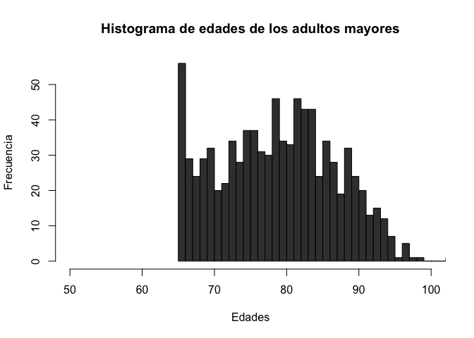

```r
hist(efc$e17age,
     main="Histograma de edades de los adultos mayores",
     xlab="Edades",
     ylab = "Frecuencia",
     border="black",
     col="#3d3d3d",
     xlim=c(50,100),
     breaks=50
     )
```

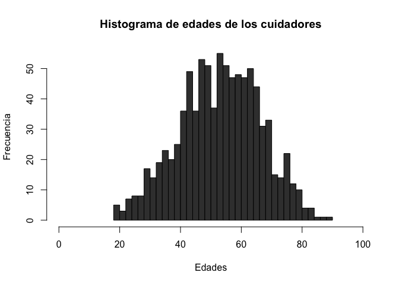

```r
hist(efc$c160age,
     main="Histograma de edades de los cuidadores",
     xlab="Edades",
     ylab = "Frecuencia",
     border="black",
     col="#3d3d3d",
     xlim=c(0,100),
     breaks=50
     )
```

**Outliers y distribución de variables**

4. Obtenga un `boxplot` para las variables previamente mencionadas. ¿Existen valores atípicos u *outliers*?

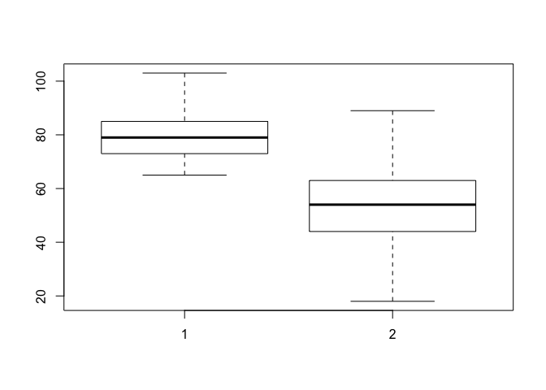

```r
boxplot(efc$e17age, efc$c160age)
```

No existen valores atípicos u outliers.